# covid

Cristopher Valenzuela

21 de febrero de 2022

Este ejercicio tiene un doble objetivo - Implementar y ejecutar un pipeline básico de análisis de datos de RNA-seq, adaptándolo de otros pre-existentes. - Aplicar dicho pipe-line al análisis de unos datos públicos que se proporcionan con este fin. - Un tercer objetivo, que puede considerarse implícito en lo anterior es comunicar el proceso y los resultado siguiendo los estándares habituales de ciencia de datos (R/Rmarkdown).

Cargamos los datos que se utilizaran.

```r
rownames(counts) = counts[,1]
counts = counts[,-1]
```

Estandarización de los contajes } Además de filtrar, es bueno expresar los contajes en “CPMs” es decir “counts per million”, lo que no modificará los resultados del filtraje, pero estandarizará los valores, lo que es útil y necesario para los análisis posteriores.

Para la estandarización se utilizará la función cpm() del paquete edgeR.

```r
#Se estandarizan los datos
library(edgeR)
counts.CPM <- cpm(counts)
```

Una vez los datos estan como CPMs, se procede a filtrarlos

Filtraje de genes poco expresados

Los genes con recuentos muy bajos en todas las librerías proporcionan poca evidencia de expresión diferencial por lo que es habitual eliminar aquellos genes que, o bien son poco variables, o bien presentan poca o nula expresión en la mayoría de las muestras.

En este caso, siguiendo las indicaciones proporcionadas, se opta por conservar únicamente aquellos genes que presentan algún valor en, al menos, tres muestras de cada grupo.

```r
thresh <- counts.CPM > 0
keep <- (rowSums(thresh[,1:17]) >= 3) &
        (rowSums(thresh[,18:34]) >= 3)
counts.keep <- counts.CPM[keep,]
dim(counts.CPM)
```

```
## [1] 60683    34
```

```r
dim(counts.keep)
```

```
## [1] 34735    34
```

```r
head(counts.CPM)
```

```
##                     COV145     COV147    COV149     COV150     COV151    COV152
## ENSG00000223972 0.00000000 0.00000000 0.0000000 0.00000000 0.00000000 0.0000000
## ENSG00000227232 0.06644967 0.00000000 0.2218932 0.84819243 0.07320991 0.1506093
## ENSG00000278267 0.19934902 0.07170342 0.1479288 0.00000000 0.21962973 0.0000000
## ENSG00000243485 0.13289935 0.00000000 0.0000000 0.05301203 0.00000000 0.0000000
## ENSG00000284332 0.00000000 0.00000000 0.0000000 0.00000000 0.00000000 0.0000000
## ENSG00000237613 0.00000000 0.00000000 0.0000000 0.00000000 0.00000000 0.0000000
##                   COV153     COV154    COV155    COV156    COV157    COV175
## ENSG00000223972 0.000000 0.00000000 0.1163313 0.0000000 0.1173623 0.0000000
## ENSG00000227232 1.388085 0.41957493 1.1633130 0.0000000 0.1173623 0.0000000
## ENSG00000278267 0.000000 0.06992916 0.1744970 0.1279917 0.1173623 0.2236183
## ENSG00000243485 0.000000 0.00000000 0.0000000 0.0000000 0.0000000 0.0000000
## ENSG00000284332 0.000000 0.00000000 0.0000000 0.0000000 0.0000000 0.0000000
## ENSG00000237613 0.000000 0.00000000 0.0000000 0.0000000 0.0000000 0.0000000
##                    COV176    COV177    COV178    COV179    COV180    HEA061
## ENSG00000223972 0.0000000 0.0000000 0.0575402 0.0000000 0.0000000 0.0000000
## ENSG00000227232 0.9503052 1.9885554 0.1726206 0.1462825 0.6558384 0.3528731
## ENSG00000278267 0.2193012 0.4349965 0.0000000 0.2194237 0.0000000 0.2352487
## ENSG00000243485 0.0000000 0.0000000 0.0000000 0.0000000 0.0000000 0.0000000
## ENSG00000284332 0.0000000 0.0000000 0.0000000 0.0000000 0.0000000 0.0000000
## ENSG00000237613 0.0000000 0.0000000 0.0000000 0.0000000 0.0000000 0.0000000
##                    HEA062    HEA063     HEA064    HEA065     HEA066    HEA067
## ENSG00000223972 0.0000000 0.0000000 0.06183451 0.0000000 0.00000000 0.0000000
## ENSG00000227232 0.0000000 0.0000000 0.06183451 0.1029819 0.05475139 0.0000000
## ENSG00000278267 0.2880235 0.1926772 0.49467608 0.1544729 0.49276252 0.4268581
## ENSG00000243485 0.0000000 0.0000000 0.00000000 0.0000000 0.00000000 0.0000000
## ENSG00000284332 0.0000000 0.0000000 0.00000000 0.0000000 0.00000000 0.0000000
## ENSG00000237613 0.0000000 0.0000000 0.00000000 0.0000000 0.00000000 0.0000000
##                     HEA068     HEA069     HEA070    HEA071    HEA181    HEA182
## ENSG00000223972 0.00000000 0.00000000 0.00000000 0.0000000 0.0000000 0.0000000
## ENSG00000227232 0.06713275 0.06693886 0.04887949 0.1122282 0.2003508 0.2800970
## ENSG00000278267 0.13426549 0.46857204 0.09775898 0.3366846 0.2003508 0.1400485
## ENSG00000243485 0.00000000 0.00000000 0.00000000 0.0561141 0.0000000 0.0000000
## ENSG00000284332 0.00000000 0.00000000 0.00000000 0.0000000 0.0000000 0.0000000
## ENSG00000237613 0.00000000 0.00000000 0.00000000 0.0000000 0.0000000 0.0000000
##                     HEA183   HEA184    HEA185    HEA186
## ENSG00000223972 0.00000000 0.000000 0.0000000 0.0000000
## ENSG00000227232 0.05465108 0.000000 0.0000000 0.4151761
## ENSG00000278267 0.32790646 0.698591 0.3036215 0.1779326
## ENSG00000243485 0.00000000 0.000000 0.0000000 0.0000000
## ENSG00000284332 0.00000000 0.000000 0.0000000 0.0000000
## ENSG00000237613 0.00000000 0.000000 0.0000000 0.0000000
```

```r
head(counts.keep)
```

```
##                     COV145     COV147    COV149     COV150     COV151
## ENSG00000227232 0.06644967 0.00000000 0.2218932 0.84819243 0.07320991
## ENSG00000278267 0.19934902 0.07170342 0.1479288 0.00000000 0.21962973
## ENSG00000233750 0.06644967 0.07170342 0.0000000 0.05301203 0.07320991
## ENSG00000268903 1.19609411 0.71703416 0.2958576 0.42409621 2.41592702
## ENSG00000269981 0.73094640 0.07170342 0.3698219 0.37108419 1.68382792
## ENSG00000241860 0.06644967 0.00000000 0.1479288 0.05301203 0.51246937
##                     COV152    COV153     COV154   COV155    COV156     COV157
## ENSG00000227232 0.15060933 1.3880853 0.41957493 1.163313 0.0000000 0.11736232
## ENSG00000278267 0.00000000 0.0000000 0.06992916 0.174497 0.1279917 0.11736232
## ENSG00000233750 0.00000000 0.0000000 0.13985831 0.000000 0.0000000 0.05868116
## ENSG00000268903 0.75304664 0.6169268 0.90907902 1.570473 1.2159212 0.46944927
## ENSG00000269981 0.07530466 0.3084634 1.25872480 1.046982 1.5359005 0.29340579
## ENSG00000241860 0.15060933 0.1542317 0.13985831 0.174497 0.3199793 0.17604348
##                    COV175    COV176    COV177    COV178     COV179    COV180
## ENSG00000227232 0.0000000 0.9503052 1.9885554 0.1726206 0.14628246 0.6558384
## ENSG00000278267 0.2236183 0.2193012 0.4349965 0.0000000 0.21942369 0.0000000
## ENSG00000233750 0.0000000 0.1462008 0.0000000 0.0000000 0.07314123 0.0000000
## ENSG00000268903 0.8199336 0.6579036 0.8078506 0.6904824 0.51198862 0.8015803
## ENSG00000269981 0.4472365 0.6579036 0.9942777 0.3452412 0.14628246 0.2186128
## ENSG00000241860 0.2236183 0.3655020 0.3107118 0.0575402 0.21942369 0.1457419
##                    HEA061    HEA062    HEA063     HEA064     HEA065     HEA066
## ENSG00000227232 0.3528731 0.0000000 0.0000000 0.06183451 0.10298192 0.05475139
## ENSG00000278267 0.2352487 0.2880235 0.1926772 0.49467608 0.15447288 0.49276252
## ENSG00000233750 0.0000000 0.0000000 0.0000000 0.06183451 0.05149096 0.00000000
## ENSG00000268903 0.5293096 1.0368846 0.8991604 0.24733804 0.41192767 0.49276252
## ENSG00000269981 0.6469340 0.5184423 0.1284515 0.49467608 0.25745480 0.32850835
## ENSG00000241860 0.1176244 0.1152094 0.4495802 0.12366902 0.00000000 0.05475139
##                     HEA067     HEA068     HEA069     HEA070    HEA071
## ENSG00000227232 0.00000000 0.06713275 0.06693886 0.04887949 0.1122282
## ENSG00000278267 0.42685808 0.13426549 0.46857204 0.09775898 0.3366846
## ENSG00000233750 0.12195945 0.00000000 0.06693886 0.00000000 0.0561141
## ENSG00000268903 1.03665534 0.40279648 0.53551090 0.29327693 0.7855974
## ENSG00000269981 1.03665534 0.40279648 0.53551090 0.24439745 0.7855974
## ENSG00000241860 0.06097973 0.33566373 0.13387772 0.04887949 0.3366846
##                     HEA181     HEA182     HEA183    HEA184    HEA185     HEA186
## ENSG00000227232 0.20035083 0.28009698 0.05465108 0.0000000 0.0000000 0.41517606
## ENSG00000278267 0.20035083 0.14004849 0.32790646 0.6985910 0.3036215 0.17793260
## ENSG00000233750 0.00000000 0.07002425 0.05465108 0.0000000 0.0607243 0.05931087
## ENSG00000268903 0.53426887 0.70024245 0.32790646 0.2910796 0.4250701 0.83035212
## ENSG00000269981 0.40070166 1.12038792 0.21860431 0.4075114 0.0607243 0.77104126
## ENSG00000241860 0.06678361 0.70024245 0.10930215 0.3492955 0.0000000 0.29655433
```

creamos el target para nuestros datos

```r
muestras<- colnames(counts)
grupos <- c(rep("COVID", 17), rep("SANO", 17))
colores=c(rep("red", 17), rep("blue", 17))
targets <- data.frame(sample=muestras,
                      group=grupos, cols=colores)
rownames(targets) <- targets[,1]
```

Uso de clases específicas para manejar los datos

Cuando se trabaja con distintos objetos referidos a unos mismos datos, como la matriz de contajes y el objeto “targets”, es útil disponer de clases contenedoras que permitan trabajar con todos ellos a la vez, lo que no sólo facilita el trabajo sino que ayuda a evitar “desincronizaciones”.

Éste es el caso de la clase ExpressionSet habitualmente utilizada con microarrays o de la clase que la generaliza, llamada SummarizedExperiment.

Para datos de contaje es habitual usar una clase similar a ExpressionSet llamada DGEList” pensadas para manejar datos de contajes , definida en el paquete edgeR. Esta clase, más simple que las anteriores, utiliza listas para almacenar recuentos de “reads” e información asociada de tecnologías de secuenciación o expresión génica digital. Puede encontrarse información al respecto en la ayuda del paquete edgeR.

```r
dgeObj <- DGEList(counts = counts.keep,
                  lib.size = colSums(counts.keep),
                  norm.factors = rep(1,ncol(counts.keep)),
                  samples = targets,
                  group = targets$group,
                  genes = rownames(counts.keep),
                  remove.zeros = FALSE)
dgeObj
```

```
## An object of class "DGEList"
## $counts
##                     COV145     COV147    COV149     COV150     COV151
## ENSG00000227232 0.06644967 0.00000000 0.2218932 0.84819243 0.07320991
## ENSG00000278267 0.19934902 0.07170342 0.1479288 0.00000000 0.21962973
## ENSG00000233750 0.06644967 0.07170342 0.0000000 0.05301203 0.07320991
## ENSG00000268903 1.19609411 0.71703416 0.2958576 0.42409621 2.41592702
## ENSG00000269981 0.73094640 0.07170342 0.3698219 0.37108419 1.68382792
##                     COV152    COV153     COV154   COV155    COV156     COV157
## ENSG00000227232 0.15060933 1.3880853 0.41957493 1.163313 0.0000000 0.11736232
## ENSG00000278267 0.00000000 0.0000000 0.06992916 0.174497 0.1279917 0.11736232
## ENSG00000233750 0.00000000 0.0000000 0.13985831 0.000000 0.0000000 0.05868116
## ENSG00000268903 0.75304664 0.6169268 0.90907902 1.570473 1.2159212 0.46944927
## ENSG00000269981 0.07530466 0.3084634 1.25872480 1.046982 1.5359005 0.29340579
##                    COV175    COV176    COV177    COV178     COV179    COV180
## ENSG00000227232 0.0000000 0.9503052 1.9885554 0.1726206 0.14628246 0.6558384
## ENSG00000278267 0.2236183 0.2193012 0.4349965 0.0000000 0.21942369 0.0000000
## ENSG00000233750 0.0000000 0.1462008 0.0000000 0.0000000 0.07314123 0.0000000
## ENSG00000268903 0.8199336 0.6579036 0.8078506 0.6904824 0.51198862 0.8015803
## ENSG00000269981 0.4472365 0.6579036 0.9942777 0.3452412 0.14628246 0.2186128
##                    HEA061    HEA062    HEA063     HEA064     HEA065     HEA066
## ENSG00000227232 0.3528731 0.0000000 0.0000000 0.06183451 0.10298192 0.05475139
## ENSG00000278267 0.2352487 0.2880235 0.1926772 0.49467608 0.15447288 0.49276252
## ENSG00000233750 0.0000000 0.0000000 0.0000000 0.06183451 0.05149096 0.00000000
## ENSG00000268903 0.5293096 1.0368846 0.8991604 0.24733804 0.41192767 0.49276252
## ENSG00000269981 0.6469340 0.5184423 0.1284515 0.49467608 0.25745480 0.32850835
##                    HEA067     HEA068     HEA069     HEA070    HEA071    HEA181
## ENSG00000227232 0.0000000 0.06713275 0.06693886 0.04887949 0.1122282 0.2003508
## ENSG00000278267 0.4268581 0.13426549 0.46857204 0.09775898 0.3366846 0.2003508
## ENSG00000233750 0.1219595 0.00000000 0.06693886 0.00000000 0.0561141 0.0000000
## ENSG00000268903 1.0366553 0.40279648 0.53551090 0.29327693 0.7855974 0.5342689
## ENSG00000269981 1.0366553 0.40279648 0.53551090 0.24439745 0.7855974 0.4007017
##                     HEA182     HEA183    HEA184    HEA185     HEA186
## ENSG00000227232 0.28009698 0.05465108 0.0000000 0.0000000 0.41517606
## ENSG00000278267 0.14004849 0.32790646 0.6985910 0.3036215 0.17793260
## ENSG00000233750 0.07002425 0.05465108 0.0000000 0.0607243 0.05931087
## ENSG00000268903 0.70024245 0.32790646 0.2910796 0.4250701 0.83035212
## ENSG00000269981 1.12038792 0.21860431 0.4075114 0.0607243 0.77104126
## 34730 more rows ...
##
## $samples
##        group lib.size norm.factors sample group.1 cols
## COV145 COVID 999844.4            1 COV145   COVID  red
## COV147 COVID 999518.1            1 COV147   COVID  red
## COV149 COVID 999650.3            1 COV149   COVID  red
## COV150 COVID 999884.1            1 COV150   COVID  red
## COV151 COVID 999915.0            1 COV151   COVID  red
## 29 more rows ...
##
## $genes
##                           genes
## ENSG00000227232 ENSG00000227232
## ENSG00000278267 ENSG00000278267
## ENSG00000233750 ENSG00000233750
## ENSG00000268903 ENSG00000268903
## ENSG00000269981 ENSG00000269981
## 34730 more rows ...
```

Normalización

Además de estandarizar los contajes, es importante eliminar otros los sesgos de composición entre librerías. Esto puede hacerse aplicando la normalización por el método TMM que genera un conjunto de factores de normalización, donde el producto de estos factores y los tamaños de librería definen el tamaño efectivo de la biblioteca.

La función calcNormFactors, de la librería edgeR, calcula los factores de normalización entre librerías.

Esto no modificará la matriz de contajes, pero actualizará los factores de normalización en el objeto DGEList (sus valores predeterminados son 1).

```r
library(edgeR)
dgeObj_norm <- calcNormFactors(dgeObj)

log2count_norm <- cpm(dgeObj_norm, log=TRUE)
```

Exploración de los datos

Una vez descartados los genes poco expresados y con los recuentos almacenados en un objeto DGEList, podemos`proceder a realizar algunos gráficos exploratorios para determinar si los datos aparentan buena calidad y/o si presentan algun problema.

Distribución de los contajes

Un diagrama de cajas con los datos, normalizados o no, muestra que la distribución de los contajes es muy asimétrica, lo que justifica la decisión de trabajar con los logaritmos de los datos.

La transformación logarítmica puede hacerse directamente pero es mejor usar la función cpm, como se ha hecho, que agrega una pequeña cantidad para evitar tomar logaritmos de cero.

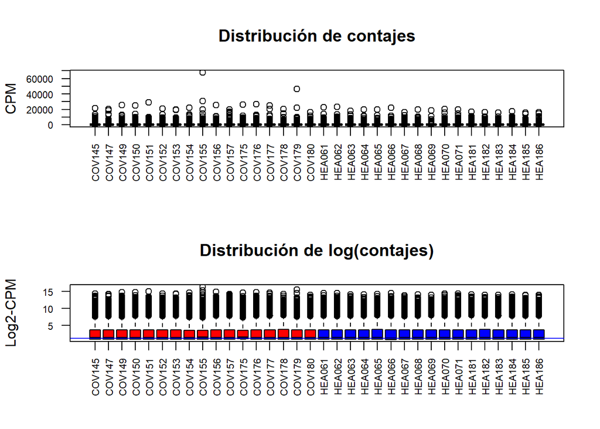

```r
par(mfrow=c(2,1))
rawCounts <- dgeObj_norm$counts
boxplot(rawCounts, ylab="CPM",las=2, xlab="", col = dgeObj$samples$cols, cex.axis=0.7, main="Distribución de contajes")
boxplot(log2count_norm, ylab="Log2-CPM",las=2, xlab="", col=dgeObj$samples$cols, cex.axis=0.7, main="Distribución de log(contajes)")
abline(h=median(log2count_norm), col="blue")
```

```r
par(mfrow=c(1,1))
```

Análisis de similaridad entre las muestras

En general, en un estudio experimental en donde buscamos comparar distintas condiciones o tratamientos, esperaremos que las muestras pertencientes al mismo grupo se parezcan más entre ellas que a las de los otros grupos.

Esta idea intuitiva puede concretarse a través de calcular y visualizar de alguna forma la similaridad entre las muestras.

Esto puede hacerse de distintas formas, pero algunas de las más habituales son, el cluster o agrupamiento jerárquico y los métodos de reducción de la dimensión como el análisis de componentes principales (PCA) o el escalamiento multidimensional (MDS). Éste último tiene la ventaja que permite visualizar en dimensión reducida las similaridades entre muestras, más que los datos directos que es lo que hace el PCA.

Distancia entre muestras

La función dist permite calcular una matriz de distancias que contiene las comparaciones dos a dos entre todas las muestras. Por defecto se utiliza una distancia euclídea.

```r
sampleDists <- dist(t(log2count_norm))
round(sampleDists,1)
```

```
##        COV145 COV147 COV149 COV150 COV151 COV152 COV153 COV154 COV155 COV156
## COV147   79.6
## COV149   70.5   81.9
## COV150   89.7   72.0   69.1
## COV151   87.5   95.9   62.2   70.7
## COV152   72.5   68.4   60.9   60.0   69.5
## COV153   93.7   66.3   82.5   74.2   90.2   72.7
## COV154   91.3   97.8   82.2   86.8   74.4   91.4  100.0
## COV155  109.4  111.8   87.5   92.5   72.9   95.8  105.8   93.0
## COV156   92.9   95.6   80.7   84.6   70.0   85.0   89.1   69.4   89.5
## COV157   95.2   73.1   79.2   63.9   82.5   64.3   68.5   97.5   95.7   88.8
## COV175  102.7  111.9   81.6  102.7   78.0   96.9  108.2   86.7   87.0   71.5
## COV176   86.5   85.2   69.7   68.4   62.5   70.4   84.9   77.8   71.0   76.4
## COV177   83.1   76.5   69.9   69.3   70.0   64.0   73.3   88.4   79.9   82.5
## COV178   72.0   65.5   68.1   65.8   75.3   55.6   70.9   91.1   96.2   82.5
## COV179   83.2   90.1   68.8   82.1   77.3   68.3   85.8  102.4   89.0   92.2
## COV180  100.4   85.1   83.8   74.4   90.5   72.5   84.8  114.9  105.8  108.8
## HEA061   52.2   80.1   66.6   87.5   84.8   70.1   89.2   95.8  110.7   93.7
## HEA062   47.5   76.4   75.7   90.7   92.7   77.5   89.9   96.8  111.5   98.9
## HEA063   50.6   71.9   79.3   88.6   96.8   73.6   88.6   99.2  115.2  100.5
## HEA064   51.8   72.6   73.3   88.5   94.3   69.3   84.3  104.2  117.0  100.2
## HEA065   56.3   67.0   73.1   78.5   86.7   66.9   80.2   86.8  109.0   87.3
## HEA066   45.5   87.8   75.5   94.1   87.8   81.2  101.8   85.1  110.3   90.4
## HEA067   58.4   66.6   73.8   83.6   92.8   68.3   75.9   98.3  112.7   97.3
## HEA068   50.7   76.4   76.1   92.5   96.5   73.8   90.1  101.1  120.8   99.7
## HEA069   59.5   76.8   85.4   95.3  102.2   80.5   91.9  104.6  122.3  106.3
## HEA070   49.5   74.2   76.0   88.0   93.6   70.9   90.6   99.6  117.3  100.0
## HEA071   55.9   72.6   71.7   82.2   88.1   70.2   86.6   92.8  107.3   95.0
## HEA181   68.1   90.0   79.4   93.2   94.8   78.8  102.7  107.3  117.3  104.7
## HEA182   74.4   89.8   78.3   92.0   95.7   78.8   94.6  110.6  114.3  107.8
## HEA183   72.8   84.9   85.8   93.3  102.4   81.7   99.9  111.8  121.0  109.8
## HEA184   69.0   84.7   77.0   89.6   93.9   74.4   95.8  108.2  116.2  104.5
## HEA185   72.0   83.6   83.4   88.7   98.7   78.3   96.0  107.9  118.8  108.1
## HEA186   73.1   83.8   81.2   90.6   99.2   76.0   95.2  111.8  118.5  105.0
##        COV157 COV175 COV176 COV177 COV178 COV179 COV180 HEA061 HEA062 HEA063
## COV147
## COV149
## COV150
## COV151
## COV152
```

[output cut: 81 more lines]

```
## HEA063
## HEA064
## HEA065
## HEA066
## HEA067
## HEA068
## HEA069
## HEA070
## HEA071
## HEA181
## HEA182
## HEA183
## HEA184   48.6
## HEA185   49.6   53.4
## HEA186   53.0   52.4   58.3
```

Las matrices de distancias se pueden visualizar directamente con un heatmap

```r
library(factoextra)
```

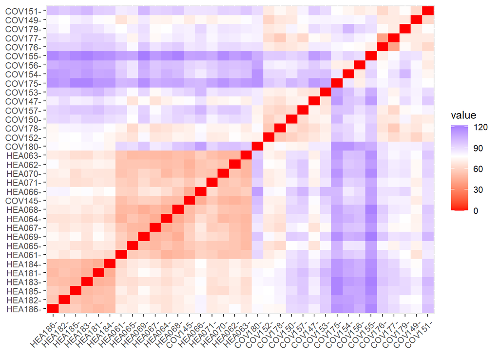

```r
fviz_dist(sampleDists)
```

Agrupamiento jerárquico

Un agrupamiento jerárquico proporciona una representación alternativa, también basada en la matriz de distancias.

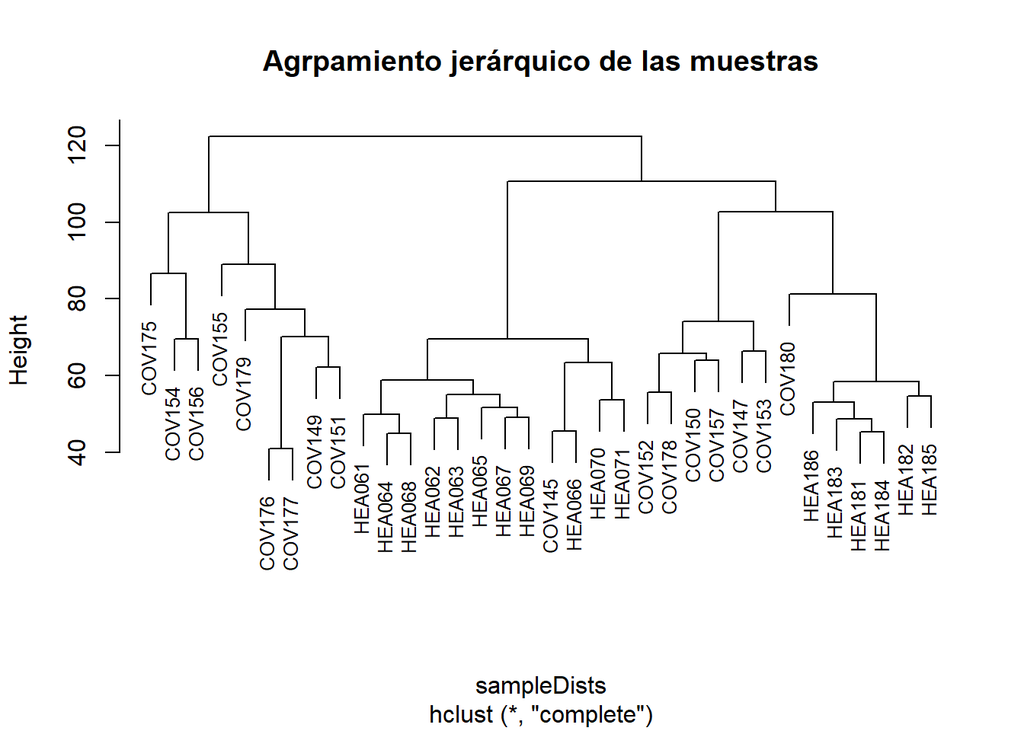

```r
hc <-hclust(sampleDists)
plot(hc,labels = colnames(log2count_norm),main = "Agrpamiento jerárquico de las muestras", cex=0.8)
```

Una forma adicional de comprobar que, efectivamente, la mustra “COV155” difiere de las demas es verificar que el factor de normalización de dicha muestra es distinto al de los demás, lo que es coherente con el resto de visualizaciones y sugiere que es preciso un mayor esfuerzo para hacerla similar al resto.

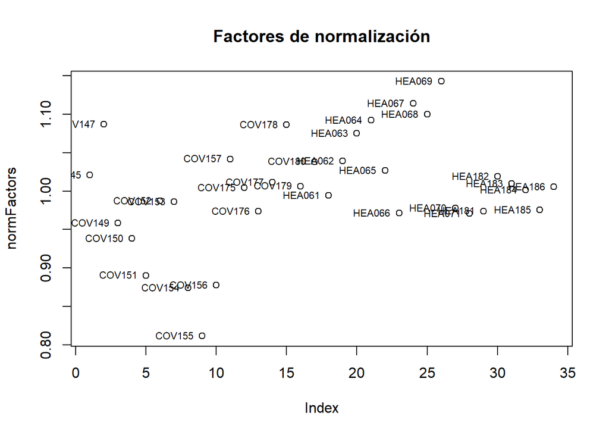

```r
normFactors <- dgeObj_norm$samples$norm.factors
names(normFactors)<- sampleNames <- rownames(dgeObj_norm$samples)
plot(normFactors, main= "Factores de normalización")
text(normFactors, sampleNames, pos=2, cex=0.7)
```

Visualización en dimensión reducida

Un enfoque complementario para determinar las principales fuentes de variabilidad en los datos es la visualización en dimensión reducida, ya sea de los datos o de la matriz de similaridades.

Para la primera representación es habitual basarse en el resultado de un análisis de componentes principales (PCA) que representan las direcciones a lo largo de las cuales la variación en la matriz de datos es máxima, con la ventaja de que dichas direcciones son ortogonales (es decir independientes) y que explica cada una más información que la siguiente, por lo que con unas pocas dimensiones se suele poder explicar un alto porcentaje de la variabilidad.

De forma análoga, el escalamiento multidimensional permite llevar a cabo una transformación similar a la del PCA, pero con la matriz de distancias, lo que proporciona una representación en dimensión reducida que describe con relativa fidelidad las diferencias y similaridades entre muestras.

Para esta segunda representación utilizaremos la función plotMDS. Es un poco difícil ver exactamente qué está pasando con la gráfica predeterminada, aunque vemos muestras que se agrupan en pares. Para hacer esta gráfica más informativa, podemos colorear las muestras de acuerdo con la información de agrupación (por ejemplo. Estado):

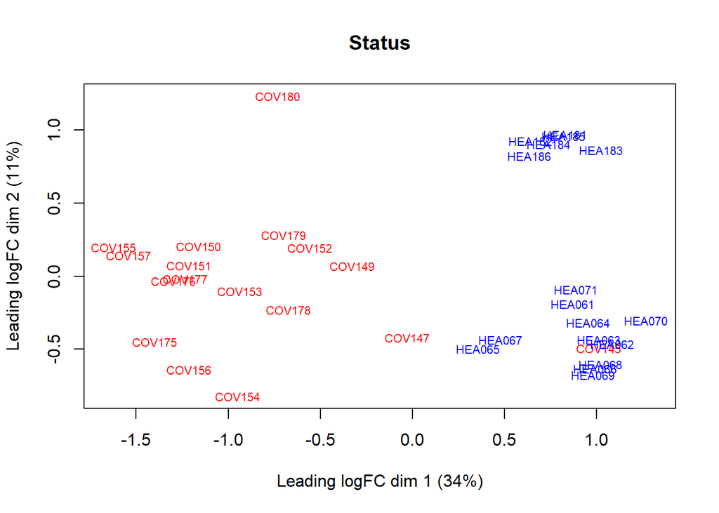

```r
col.status <- dgeObj_norm$samples$cols
plotMDS(log2count_norm,col=col.status, main="Status", cex=0.7)
```

En general vemos que las muestras se agrupan naturalmente.

En este caso como no hay covariables no analizamos el efecto de lotes, y la agrupacion natural de las muestras parece ser un ejemplo de esto.

Análisis de expresión diferencial

El objetivo del análisis de expresión diferencial es seleccionar genes cuya expresión difiere entre grupos.

Al tratarse de contajes, que no son variables contínuas, la comparación puede llevarse a cabo usando modelos lineales generalizados o extensiones de éstos, creadas específicamente para datos de secuenciación.

Este es el caso específicamente de edgeR o DESEQ2.

Una alternativa a estos paquetes es usar el paquete limma, que ofrece la función voom, que transforma los recuentos de “reads” en logCMM, teniendo en cuenta la relación media-varianza en los datos (Charity W. Law et al. 2014) y permite analizarlos mediante la aproximación habitual basada en modelos lineales.

Selección de genes usando limma-Voom

La ventaja principal de esta aproximación es que permite trabajar con toda la flexibilidad de los modelos lineales para representar diseños experimentales, y, en muchos casos , aprovechar la experiencia previa del usuario en el manejo de limma.

Matriz de diseño y de contrastes

Utilizando la variable group podemos definir una matriz de diseño y, sobre ésta, los contrastes que nos interesan.

```r
group = as.factor(dgeObj_norm$samples$group)
design = model.matrix(~ 0 + group)
colnames(design) = gsub("group", "", colnames(design))
row.names(design) = sampleNames
design
```

```
##        COVID SANO
## COV145     1    0
## COV147     1    0
## COV149     1    0
## COV150     1    0
## COV151     1    0
## COV152     1    0
## COV153     1    0
## COV154     1    0
## COV155     1    0
## COV156     1    0
## COV157     1    0
## COV175     1    0
## COV176     1    0
## COV177     1    0
## COV178     1    0
## COV179     1    0
## COV180     1    0
## HEA061     0    1
## HEA062     0    1
## HEA063     0    1
## HEA064     0    1
## HEA065     0    1
## HEA066     0    1
## HEA067     0    1
## HEA068     0    1
## HEA069     0    1
## HEA070     0    1
## HEA071     0    1
## HEA181     0    1
## HEA182     0    1
## HEA183     0    1
## HEA184     0    1
## HEA185     0    1
## HEA186     0    1
## attr(,"assign")
## [1] 1 1
## attr(,"contrasts")
## attr(,"contrasts")$group
## [1] "contr.treatment"
```

Definimos los contrastes, en este caso tenemos sanos versus covid, asi que sera un solo contraste

```r
cont.matrix = makeContrasts(CONTROLvsCOVID = COVID - SANO,
levels=colnames(design))
cont.matrix
```

```
##        Contrasts
## Levels  CONTROLvsCOVID
##   COVID              1
##   SANO              -1
```

Transformación de los contajes

Tal como se ha indicado, no es posible aplicar un modelo lineal normal con datos de contajes. la transformación voom creará un nuevo objeto con campos equivalentes a los del DGELIST, en la que los contajes se han transdormado de forma que puedan ser analizados usando modelos lineales. O, mejor dicho, de forma que las inferencias realizadas, usando un modelo lineal normal resulten válidas.

```r
voomObj <- voom(dgeObj_norm, design)
voomObj
```

```
## An object of class "EList"
## $genes
##                           genes
## ENSG00000227232 ENSG00000227232
## ENSG00000278267 ENSG00000278267
## ENSG00000233750 ENSG00000233750
## ENSG00000268903 ENSG00000268903
## ENSG00000269981 ENSG00000269981
## 34730 more rows ...
##
## $targets
##        group  lib.size norm.factors sample group.1 cols
## COV145 COVID 1020786.9    1.0209457 COV145   COVID  red
## COV147 COVID 1086354.6    1.0868784 COV147   COVID  red
## COV149 COVID  958362.8    0.9586980 COV149   COVID  red
## COV150 COVID  938181.7    0.9382905 COV150   COVID  red
## COV151 COVID  890274.4    0.8903500 COV151   COVID  red
## 29 more rows ...
##
## $E
##                     COV145     COV147     COV149      COV150     COV151
## ENSG00000227232 -0.8496634 -1.1194964 -0.4087880  0.52308565 -0.6351881
## ENSG00000278267 -0.5455985 -0.9261576 -0.5647381 -0.90794078 -0.3069968
## ENSG00000233750 -0.8496634 -0.9261576 -0.9386453 -0.76255802 -0.6351881
## ENSG00000268903  0.7325332  0.1638733 -0.2680632 -0.02182581  1.7116311
## ENSG00000269981  0.2700849 -0.9261576 -0.1398533 -0.10705672  1.2945357
##                     COV152     COV153      COV154     COV155     COV156
## ENSG00000227232 -0.6011084  0.9372457  0.07374114  1.0360295 -0.8116961
## ENSG00000278267 -0.9809718 -0.9796782 -0.61644340 -0.2661464 -0.4828787
## ENSG00000233750 -0.9809718 -0.9796782 -0.44947352 -0.6980302 -0.8116961
## ENSG00000268903  0.3444683  0.1798564  0.68945462  1.3519299  0.9672872
## ENSG00000269981 -0.7785737 -0.2864239  1.00923185  0.9314260  1.2139710
##                     COV157      COV175     COV176     COV177     COV178
## ENSG00000227232 -0.7544771 -1.00502082  0.5752834  1.2991861 -0.6910945
## ENSG00000278267 -0.7544771 -0.47172010 -0.4364052 -0.1130895 -1.1189593
## ENSG00000233750 -0.8985694 -1.00502082 -0.5910187 -1.0161224 -1.1189593
## ENSG00000268903 -0.1034291  0.39544456  0.2504420  0.3710754  0.1325869
## ENSG00000269981 -0.3925356 -0.08322421  0.2504420  0.5633259 -0.3615244
##                       COV179     COV180      HEA061      HEA062     HEA063
## ENSG00000227232 -0.638547362  0.1553611 -0.22150429 -1.05572420 -1.1045388
```

[output cut: 50 more lines]

```
## [1,] 23.169378 18.240490 19.143536 19.994779 22.973405 19.525005
## [2,]  8.739504  8.127056  8.238120  8.352434  8.718735  8.289873
## [3,] 44.729686 34.455195 36.672680 38.798368 44.729686 37.621050
## [4,]  6.398839  6.207944  6.247166  6.282338  6.392687  6.263134
## [5,]  6.924686  6.650822  6.706810  6.757139  6.915805  6.729645
## 34730 more rows ...
##
## $design
##        COVID SANO
## COV145     1    0
## COV147     1    0
## COV149     1    0
## COV150     1    0
## COV151     1    0
## 29 more rows ...
```

Selección de genes diferencialmente expresados

Como en el caso de los microarrays el objeto voomObj y las matrices de diseño y contrastes se utilizaran para ajustar un modelo y, a continuación realizar las comparaciones especificadas sobre el modelo ajustado. El proceso finaliza con la regularización del estimador del error usando la función eBayes.

```r
fit <- lmFit(voomObj)
fit.cont <- contrasts.fit(fit, cont.matrix)
fit.cont <- eBayes(fit.cont)
```

Top tables

Los resultados de un análisis de expresión diferencial se pueden extraer con la función topTable. Esta función genera una tabla de resultados cuyas columnas contienen información acerca de los genes y la diferencia entre los grupos comparados.

```r
toptab <- topTable(fit.cont,coef=1,sort.by="p", number=nrow(fit.cont))
head(toptab)
```

```
##                           genes    logFC  AveExpr        t      P.Value
## ENSG00000167900 ENSG00000167900 2.838192 4.111006 12.30746 8.955654e-15
## ENSG00000090889 ENSG00000090889 2.484446 1.292007 11.82086 3.019910e-14
## ENSG00000111206 ENSG00000111206 2.430174 2.018375 11.73574 3.746800e-14
## ENSG00000166851 ENSG00000166851 3.228957 2.615481 11.60969 5.165198e-14
## ENSG00000135476 ENSG00000135476 2.244286 1.705195 11.56324 5.816975e-14
## ENSG00000187837 ENSG00000187837 1.649702 4.452143 11.45763 7.629013e-14
##                    adj.P.Val        B
## ENSG00000167900 3.110746e-10 23.43905
## ENSG00000090889 4.041053e-10 22.07079
## ENSG00000111206 4.041053e-10 21.85925
## ENSG00000166851 4.041053e-10 21.61930
## ENSG00000135476 4.041053e-10 21.42545
## ENSG00000187837 4.356529e-10 21.42220
```

Visualización de los resultados

Para visualizar los resultados podemos usar un volcanoPlot

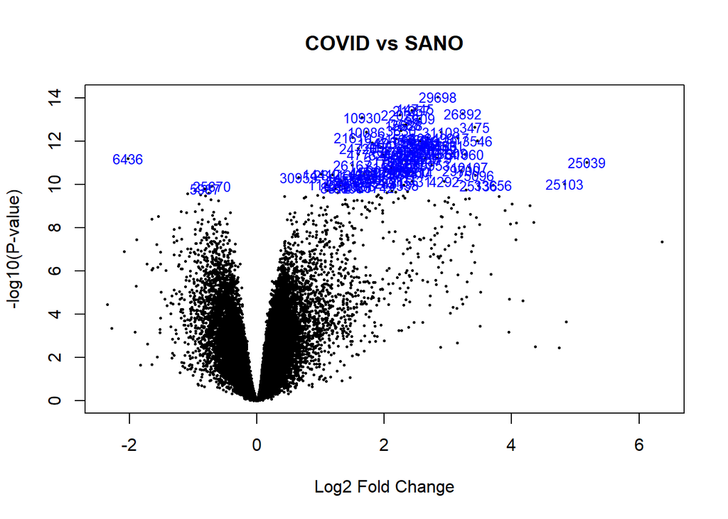

```r
volcanoplot(fit.cont,coef=1,highlight=100, main="COVID vs SANO")
```

```r
topGenesBas <- rownames(subset(toptab, (abs(logFC)> 2) & (adj.P.Val < 0.01)))
length(topGenesBas)
```

```
## [1] 200
```

Con la matriz de expresión de los genes que verifican dicha condición se puede construir un heatmap.

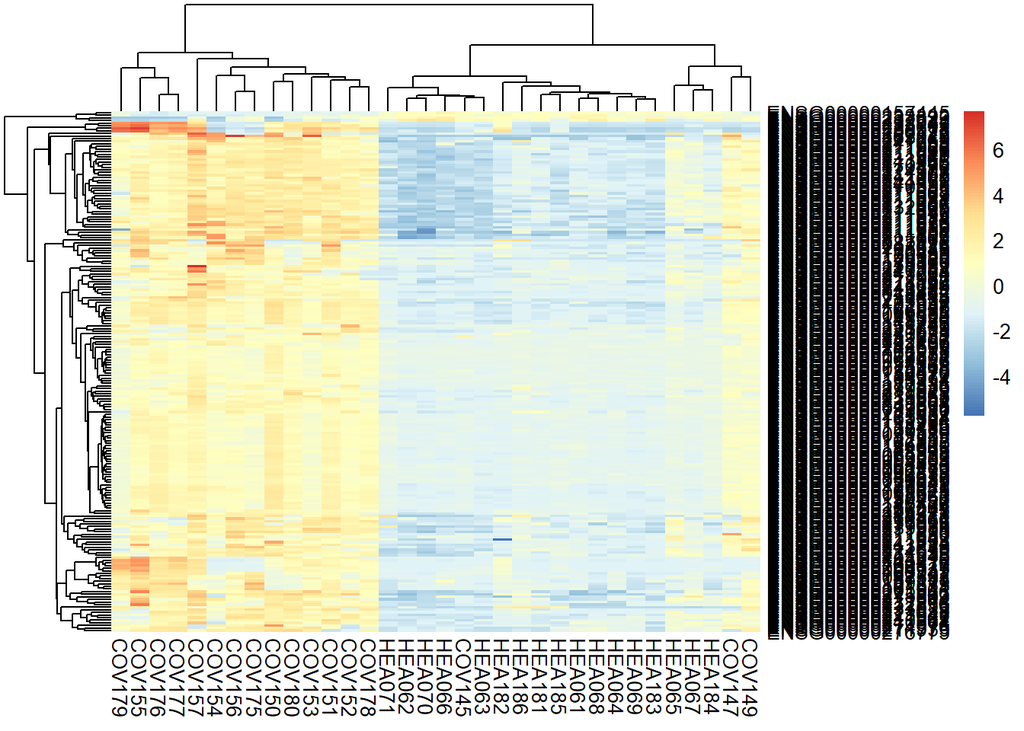

```r
library(pheatmap)
mat  <- log2count_norm[topGenesBas, ]
mat  <- mat - rowMeans(mat)
pheatmap(mat)
```

Anotación de resultados y análisis de significación biológica

Para el análisis de significación se utilizan dos listas de transcritos:

La lista de transcritos diferencialmenete expresados La lista de tosos los tránscritos o “Universo”

```r
universe <- rownames(toptab)
length(universe)
```

```
## [1] 34735
```

Anotación de los identificadores

Un detalle importante en los estudios de RNA-seq es que las unidades de expresión suelen ser tránscritos no genes. En la práctica, esto determina que la mayoría de programas de análisis de enriquecimiento pueden perder detalle, porque para su uso se requiere tener los identificadores en formato “gen”, habitualmente ENTREZ o SYMBOL.

```r
library(org.Hs.eg.db)
AnnotationDbi::keytypes(org.Hs.eg.db)
```

```
##  [1] "ACCNUM"       "ALIAS"        "ENSEMBL"      "ENSEMBLPROT"  "ENSEMBLTRANS"
##  [6] "ENTREZID"     "ENZYME"       "EVIDENCE"     "EVIDENCEALL"  "GENENAME"
## [11] "GENETYPE"     "GO"           "GOALL"        "IPI"          "MAP"
## [16] "OMIM"         "ONTOLOGY"     "ONTOLOGYALL"  "PATH"         "PFAM"
## [21] "PMID"         "PROSITE"      "REFSEQ"       "SYMBOL"       "UCSCKG"
## [26] "UNIPROT"
```

```r
topAnots = AnnotationDbi::select(org.Hs.eg.db, topGenesBas, c("SYMBOL", "ENTREZID", "GENENAME"),
keytype = "ENSEMBL")
head(topAnots)
```

```
##           ENSEMBL SYMBOL ENTREZID                                   GENENAME
## 1 ENSG00000167900    TK1     7083                         thymidine kinase 1
## 2 ENSG00000090889  KIF4A    24137                   kinesin family member 4A
## 3 ENSG00000111206  FOXM1     2305                            forkhead box M1
## 4 ENSG00000166851   PLK1     5347                         polo like kinase 1
## 5 ENSG00000135476  ESPL1     9700 extra spindle pole bodies like 1, separase
## 6 ENSG00000123485  HJURP    55355      Holliday junction recognition protein
```

```r
dim(topAnots)
```

```
## [1] 201   4
```

Anotacion para el universo

```r
univAnots = AnnotationDbi::select(org.Hs.eg.db, universe, c("SYMBOL", "ENTREZID", "GENENAME"), keytype = "ENSEMBL")
head(univAnots)
```

```
##           ENSEMBL SYMBOL ENTREZID                                   GENENAME
## 1 ENSG00000167900    TK1     7083                         thymidine kinase 1
## 2 ENSG00000090889  KIF4A    24137                   kinesin family member 4A
## 3 ENSG00000111206  FOXM1     2305                            forkhead box M1
## 4 ENSG00000166851   PLK1     5347                         polo like kinase 1
## 5 ENSG00000135476  ESPL1     9700 extra spindle pole bodies like 1, separase
## 6 ENSG00000187837   H1-2     3006        H1.2 linker histone, cluster member
```

```r
dim(univAnots)
```

```
## [1] 34905     4
```

Análisis de enriquecimiento

El paquete clusterProfiler admite identificadores de tipo ENSEMBL y permite gran variedad de análisis complementarios al enriquecimiento por lo que, es una de las mejores opcionespara el análisis de significación biológica.

En primer lugar se lleva a cabo un Análisis de enriquecimiento con categorias de la ontología “Biological Process” que permite seleccionar aquellas categorías más enriquecidas en la lista de genes diferencialmente expresados.

El objeto resultante del análisis contiene información sobre las categorías enriquecidas, el grado de enriquecimiento, o los genes anotados en las mismas. Este objeto puede salvarse a disco para su posterior consulta.

```r
library(clusterProfiler)
library(org.Hs.eg.db)
ego = enrichGO(gene = topGenesBas,
               universe=universe,
               keyType = "ENSEMBL",
               OrgDb = org.Hs.eg.db,
               ont="BP",
               pAdjustMethod = "BH",
               pvalueCutoff = 0.05,
               qvalueCutoff = 0.05,
               readable = TRUE)
```

Un dotplot muestra algunas categorias usando un código de tamaño para el número de genes en la categoría y de color para la significación.

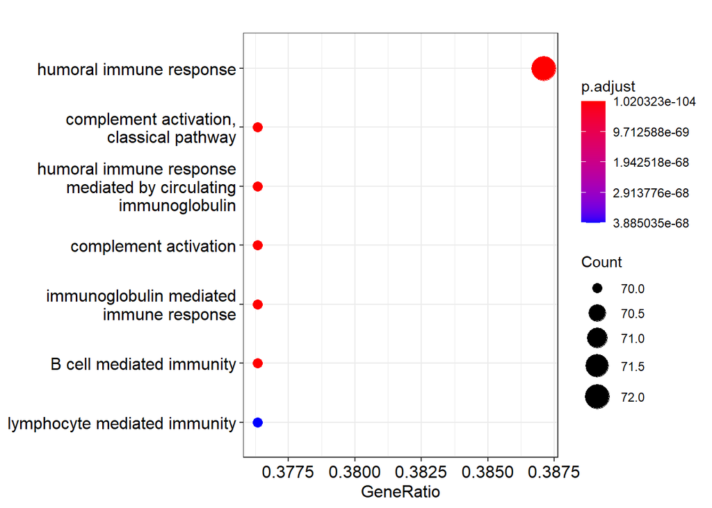

```r
dotplot(ego, showCategory=7)
```

Un cnetplot la relación entre genes y categorías enriquecidas.

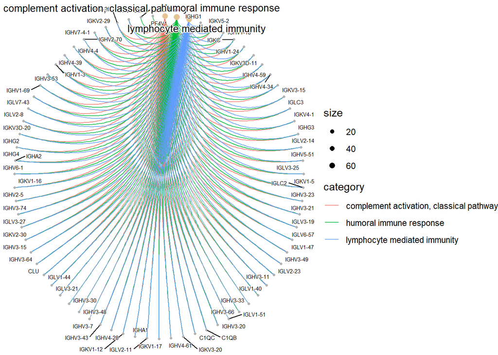

```r
library(ggplot2)
ego2 = simplify(ego)
cnetplot(ego2, showCategory = 3, cex_category =0.3,
         cex_label_category =0.7, cex_gene=0.2, cex_label_gene=0.4,
         circular=TRUE, colorEdge=TRUE)
```

Un goplot muestra, en forma de subgrafo de la Gene Ontology, las categorías que se relacionan, como ascendientes, con las categorías enriquecidas. Sirve para ver éstas, en contexto.

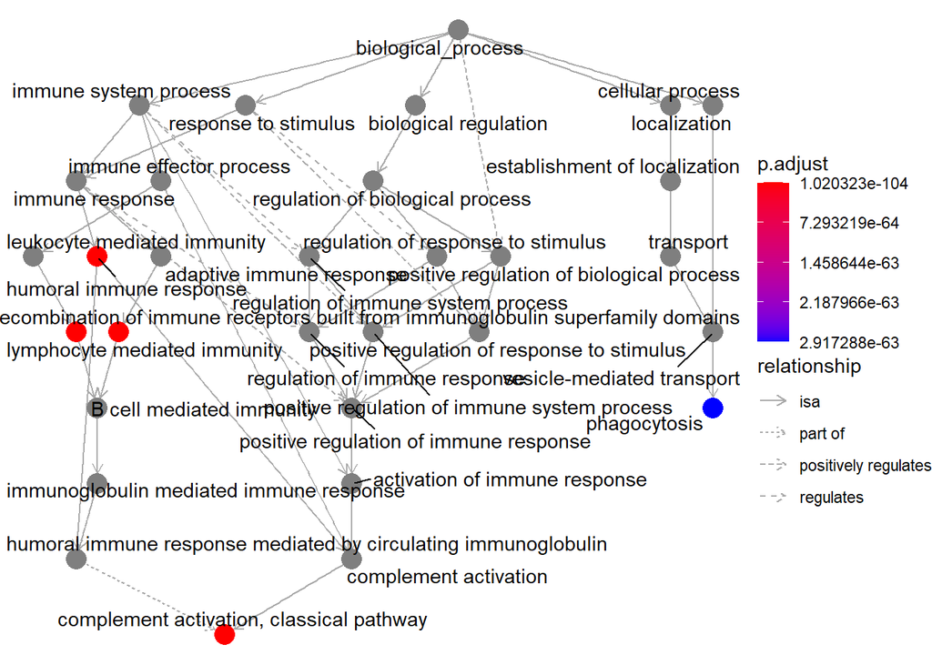

```r
library(enrichplot)
goplot(ego2, showCategory=5, cex=0.1)
```

Un heatplot`permite relacionar, de forma similar al cnetplot, las categorías y los genes anotados en ellas. Conceptualmente es interesante, pero la visibilidad es difícil.

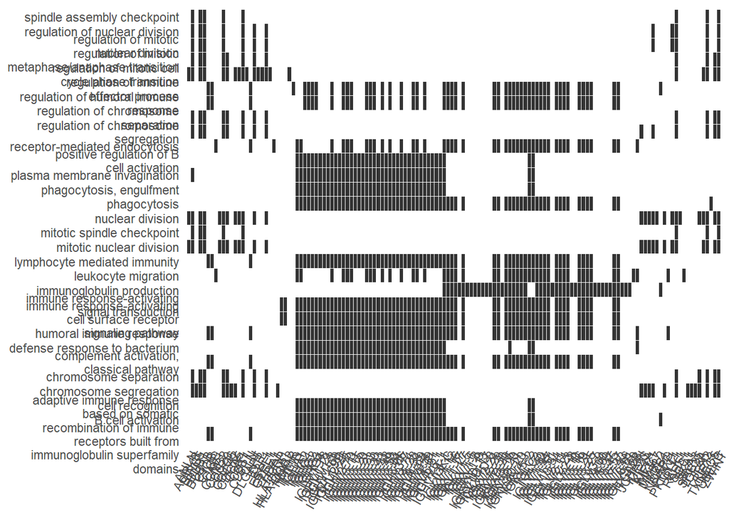

```r
heatplot(ego2)
```

Finalmente, dada la abundancia de componentes que aparecen en los análisis, podemos mirar de agruparlos por su similaridad (cercanía dentro del grafo) y así obtener una visualización más compacta.

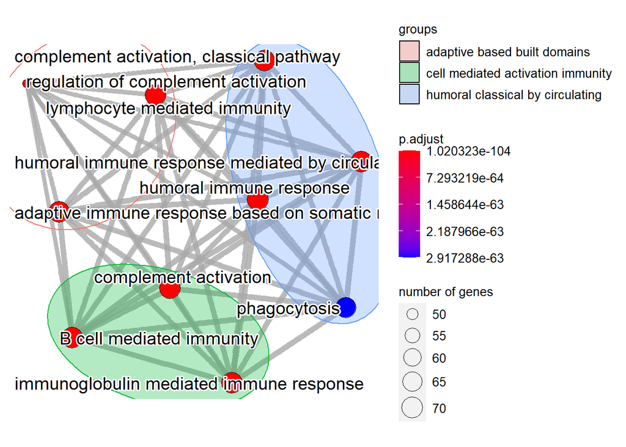

```r
term_similarity_matrix = pairwise_termsim(ego)
emapplot(term_similarity_matrix, showCategory = 10,
         group_category=TRUE, group_legend=TRUE)
```